# **Test del segundo parcial ECO II: Función de Autocorrelación Parcial**

```python
import numpy as np
```

## **Primer Ejercicio**

Se simuló una serie de tiempo integrada de orden 0 con 3000 observaciones, a continuación se muestran los valores de las autocorrelaciones simples y parciales muestrales, realice las pruebas de significancia necesarias e identifique un modelo que corresponda adecuadamente a los resultados de dichas pruebas. Entregar el desarrollo escrito de las pruebas de significancia y la justificación del modelo y región admisible correspondiente.

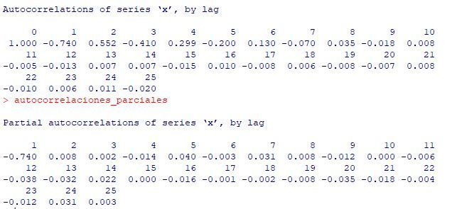

```python
N = 3000
d = 0
# Es un ARIRMA(p, 0, q)

# Suponemos que rho1 = 0
rho1 = 0

2 * np.sqrt(1 / (N-d) * (1 + 2 * (rho1) ** 2))


r1 = -0.740

if abs(r1) > 2 * np.sqrt(1 / (N-d) * (1 + 2 * (rho1) ** 2)):
    print("rho 1 es significativo")
```

```
rho 1 es significativo
```

```python
# rho 1 es significativo
rho1 = r1

# Suponemos que rho2 = 0
rho2 = 0

r2 = 0.552

if abs(r2) > 2 * np.sqrt(1 / (N-d) * (1 + 2 * (rho1 + rho2) ** 2)):
    print("rho 2 es significativo")
```

```
rho 2 es significativo
```

```python
# rho 2 es significativo
rho2 = r2

# Suponemos que rho3 = 0
rho3 = 0

r3 = -0.410

if abs(r3) > 2 * np.sqrt(1 / (N-d) * (1 + 2 * (rho1 + rho2 + rho3) ** 2)):
    print("rho 3 es significativo")
```

```
rho 3 es significativo
```

```python
# partial autocorrelation function

menosintervalo = -2*np.sqrt(1/N)
masintervalo = 2*np.sqrt(1/N)
```

```python
print(menosintervalo, masintervalo)
```

```
-0.03651483716701107 0.03651483716701107
```

### **Respuesta**

Entonces es un $\text{ARIMA(1, 0, 0)}$.

## **Segundo Ejercicio**

Se simuló una serie de tiempo integrada de orden 0 con 1000 observaciones, a continuación se muestran los valores de las autocorrelaciones simples y parciales muestrales, realice las pruebas de significancia necesarias e identifique un modelo que corresponda adecuadamente a los resultados de dichas pruebas. Entregar el desarrollo escrito de las pruebas de significancia y la justificación del modelo y región admisible correspondiente.

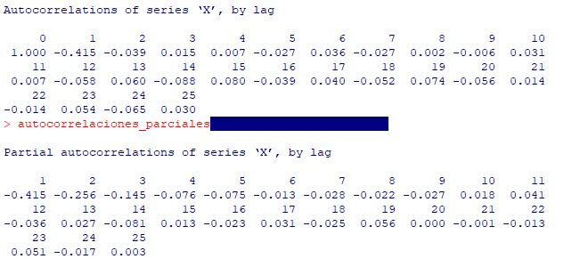

```python
def significancia(N, d, rho1, rho2, rho3):
    return 2 * np.sqrt(1 / (N-d) * (1 + 2 * (rho1**2 + rho2**2 + rho3**2)))
```

```python
def intervalo(N, d):
    return 2*np.sqrt(1/ (N-d) )
```

```python
d = 0
N = 1000
```

```python
r1 = -0.415
r2 = -0.039
r3 = 0.015
```

```python
rho1 = 0
rho2 = 0
rho3 = 0
```

```python
phi11 = -0.415
phi22 = -0.256
phi33 = -0.145
```

```python
vr1 = significancia(N, d, rho1, rho2, rho3)

if abs(r1) > vr1:
    print("rho 1 es significativo")
    print(r1, vr1)
    rho1 = r1
```

```
rho 1 es significativo
-0.415 0.06324555320336758
```

```python
vr2 = significancia(N, d, rho1, rho2, rho3)

if abs(r2) > vr2:
    print("rho 2 es significativo")
    print(r2, vr2)
    rho2 = r2
else:
    print("rho 2 no es significativo")
    print(r2, vr2)
```

```
rho 2 no es significativo
-0.039 0.07333348484832831
```

```python
vr3 = significancia(N, d, rho1, rho2, rho3)

if abs(r3) > vr3:
    print("rho 3 es significativo")
    print(r3, vr3)
    rho3 = r3
else:
    print("rho 3 no es significativo")
    print(r3, vr3)
```

```
rho 3 no es significativo
0.015 0.07333348484832831
```

```python
intervalo(N, d)
```

```
0.06324555320336758
```

### **Respuesta**

Entonces es un $\text{ARIMA(0, 0, 1)}$.

## **Tercer Ejercicio**

Se simuló una serie de tiempo integrada de orden 0 con 1000 observaciones, a continuación se muestran los valores de las autocorrelaciones simples y parciales muestrales, realice las pruebas de significancia necesarias e identifique un modelo que corresponda adecuadamente a los resultados de dichas pruebas. Entregar el desarrollo escrito de las pruebas de significancia y la justificación del modelo y región admisible correspondiente.

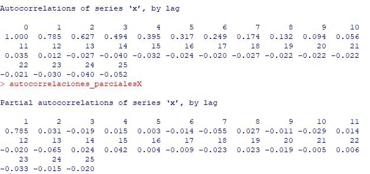

```python
N = 1000
d = 0
```

```python
r1 = 0.785
r2 = 0.627
r3 = 0.494
```

```python
phi11 = 0.785
phi22 = 0.031
phi33 = -0.019
```

```python
rho1 = 0
rho2 = 0
rho3 = 0
```

```python
vr1 = significancia(N, d, rho1, rho2, rho3)
if abs(r1) > vr1:
    print("rho 1 es significativo")
    print(r1, vr1)
    rho1 = r1
else :
    print("rho 1 no es significativo")
    print(r1, vr1)
```

```
rho 1 es significativo
0.785 0.06324555320336758
```

```python
vr2 = significancia(N, d, rho1, rho2, rho3)

if abs(r2) > vr2:
    print("rho 2 es significativo")
    print(r2, vr2)
    rho2 = r2
else:
    print("rho 2 no es significativo")
    print(r2, vr2)
```

```
rho 2 es significativo
0.627 0.09449761901762394
```

```python
vr3 = significancia(N, d, rho1, rho2, rho3)

if abs(r3) > vr3:
    print("rho 3 es significativo")
    print(r3, vr3)
    rho3 = r3
else:
    print("rho 3 no es significativo")
    print(r3, vr3)
```

```
rho 3 es significativo
0.494 0.10988554045005194
```

```python
def FACP(N, d, r1, r2, r3, rho1=0, rho2=0, rho3=0):

    vr1 = significancia(N, d, rho1, rho2, rho3)
    if abs(r1) > vr1:
        print("rho 1 es significativo")
        print(r1, ">", vr1)
        rho1 = r1
    else:
        print("rho 1 no es significativo")
        print(r1,  "<", vr1)

    vr2 = significancia(N, d, rho1, rho2, rho3)
    if abs(r2) > vr2:
        print("rho 2 es significativo")
        print(r2, ">", vr2)
        rho2 = r2
    else:
        print("rho 2 no es significativo")
        print(r2, "<",  vr2)

    vr3 = significancia(N, d, rho1, rho2, rho3)
    if abs(r3) > vr3:
        print("rho 3 es significativo")
        print(r3, ">",vr3)
        rho3 = r3
    else:
        print("rho 3 no es significativo")
        print(r3,"<",  vr3)
```

```python
FACP(1000, 0, 0.785, 0.627, 0.494)
```

```
rho 1 es significativo
0.785 > 0.06324555320336758
rho 2 es significativo
0.627 > 0.09449761901762394
rho 3 es significativo
0.494 > 0.10988554045005194
```

```python
intervalo(1000, 0)
```

```
0.06324555320336758
```

### **Respuesta**

Entonces es un $\text{ARIMA(1, 0, 0)}$.

## **Cuarto Ejercicio**

Se simuló una serie de tiempo integrada de orden 0 con 1000 observaciones, a continuación se muestran los valores de las autocorrelaciones simples y parciales muestrales, realice las pruebas de significancia necesarias e identifique un modelo que corresponda adecuadamente a los resultados de dichas pruebas. Entregar el desarrollo escrito de las pruebas de significancia y la justificación del modelo y región admisible correspondiente.

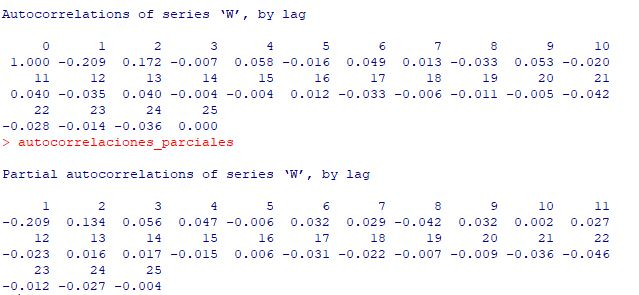

```python
def significancia(N, d, rho1, rho2, rho3, rho4, rho5):
    return 2 * np.sqrt(1 / (N-d) * (1 + 2 * (rho1**2 + rho2**2 + rho3**2 + rho4**2 + rho5**2)))
```

```python
def FACP5(N, d, r1, r2, r3, r4, r5, rho1=0, rho2=0, rho3=0, rho4=0, rho5=0):

    vr1 = significancia(N, d, rho1, rho2, rho3, rho4, rho5)
    if abs(r1) > vr1:
        print("rho 1 es significativo")
        print(abs(r1), ">", vr1)
        rho1 = r1
    else:
        print("rho 1 no es significativo")
        print(abs(r1),  "<", vr1)

    vr2 = significancia(N, d, rho1, rho2, rho3, rho4, rho5)
    if abs(r2) > vr2:
        print("\nrho 2 es significativo")
        print(abs(r2), ">", vr2)
        rho2 = r2
    else:
        print("\nrho 2 no es significativo")
        print(abs(r2), "<",  vr2)

    vr3 = significancia(N, d, rho1, rho2, rho3, rho4, rho5)
    if abs(r3) > vr3:
        print("\nrho 3 es significativo")
        print(abs(r3), ">",vr3)
        rho3 = r3
    else:
        print("\nrho 3 no es significativo")
        print(abs(r3),"<",  vr3)

    vr4 = significancia(N, d, rho1, rho2, rho3, rho4, rho5)
    if abs(r4) > vr4:
        print("\nrho 4 es significativo")
        print(abs(r4), ">",vr4)
        rho4 = r4
    else:
        print("\nrho 4 no es significativo")
        print(abs(r4),"<",  vr4)

    vr5 = significancia(N, d, rho1, rho2, rho3, rho4, rho5)
    if abs(r5) > vr5:
        print("\nrho 5 es significativo")
        print(abs(r5), ">",vr5)
        rho5 = r5
    else:
        print("\nrho 5 no es significativo")
        print(abs(r5),"<",  vr5)
```

```python
FACP5(1000, 0, -0.209, 0.172, -0.007, 0.058, -0.016)
```

```
rho 1 es significativo
0.209 > 0.06324555320336758

rho 2 es significativo
0.172 > 0.06595034495739957

rho 3 no es significativo
0.007 < 0.067720897808579

rho 4 no es significativo
0.058 < 0.067720897808579

rho 5 no es significativo
0.016 < 0.067720897808579
```

```python
intervalo(1000, 0)
```

```
0.06324555320336758
```

### **Respuesta**

Entonces es un $\text{ARIMA(0, 0, 2)}$.

## **Quinto Ejercicio**

Se simuló una serie de tiempo integrada de orden 0 con 1000 observaciones, a continuación se muestran los valores de las autocorrelaciones simples y parciales muestrales, realice las pruebas de significancia necesarias e identifique un modelo que corresponda adecuadamente a los resultados de dichas pruebas. Entregar el desarrollo escrito de las pruebas de significancia y la justificación del modelo y región admisible correspondiente.

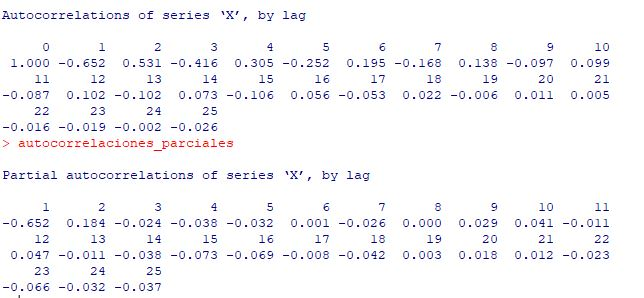

```python
FACP5(1000, 0, -0.652, 0.531, -0.416, 0.305, -0.252)
```

[output not shown]

```python
intervalo(1000, 0)
```

```
0.06324555320336758
```

### **Respuesta**

- No hay diferencias.
- Todas las autocorrelaciones simples son significativas.
- Muchas autocorrelaciones parciales son significativas.

Las opción más parecida es un $\text{ARIMA(2, 0, 0)}$.

## **Sexto Ejercicio**

Se simuló una serie de tiempo integrada de orden 0 con 1000 observaciones, a continuación se muestran los valores de las autocorrelaciones simples y parciales muestrales, realice las pruebas de significancia necesarias e identifique un modelo que corresponda adecuadamente a los resultados de dichas pruebas. Entregar el desarrollo escrito de las pruebas de significancia y la justificación del modelo y región admisible correspondiente.

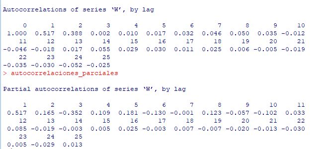

```python
FACP5(1000, 0, 0.517, 0.388, 0.002, 0.010, 0.017)
```

```
rho 1 es significativo
0.517 > 0.06324555320336758

rho 2 es significativo
0.388 > 0.07834738030081159

rho 3 no es significativo
0.002 < 0.08568934589550792

rho 4 no es significativo
0.01 < 0.08568934589550792

rho 5 no es significativo
0.017 < 0.08568934589550792
```

```python
intervalo(1000, 0)
```

```
0.06324555320336758
```

### **Respuesta**

- No hay diferencias.
- Solo las dos primeras autocorrelaciones simples son significativas.
- Muchas autocorrelaciones parciales son significativas.

Entonces es un $\text{ARIMA(0, 0, 2)}$.

## **Septimo Ejercicio**

Se simuló una serie de tiempo integrada de orden 0 con 1000 observaciones, a continuación se muestran los valores de las autocorrelaciones simples y parciales muestrales, realice las pruebas de significancia necesarias e identifique un modelo que corresponda adecuadamente a los resultados de dichas pruebas. Entregar el desarrollo escrito de las pruebas de significancia y la justificación del modelo y región admisible correspondiente.

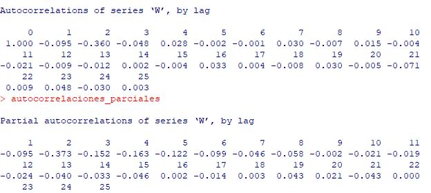

```python
FACP5(1000, 0, -0.095, -0.0360, -0.048, 0.028, -0.002)
```

```
rho 1 es significativo
0.095 > 0.06324555320336758

rho 2 no es significativo
0.036 < 0.0638137916127854

rho 3 no es significativo
0.048 < 0.0638137916127854

rho 4 no es significativo
0.028 < 0.0638137916127854

rho 5 no es significativo
0.002 < 0.0638137916127854
```

```python
intervalo(1000, 0)
```

```
0.06324555320336758
```

## **Octavo Ejercicio**

Se simuló una serie de tiempo integrada de orden 0 con 2800 observaciones, a continuación se muestran los valores de las autocorrelaciones simples y parciales muestrales, realice las pruebas de significancia necesarias e identifique un modelo que corresponda adecuadamente a los resultados de dichas pruebas. Entregar el desarrollo escrito de las pruebas de significancia y la justificación del modelo y región admisible correspondiente.

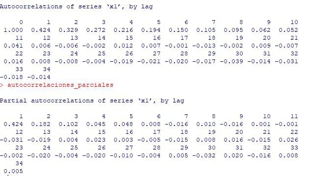

```python
FACP5(2800, 0, 0.424, 0.329, 0.272, 0.216, 0.194)
```

```
rho 1 es significativo
0.424 > 0.03779644730092272

rho 2 es significativo
0.329 > 0.04407059272187229

rho 3 es significativo
0.272 > 0.047449732800692805

rho 4 es significativo
0.216 > 0.04962721027823345

rho 5 es significativo
0.194 > 0.05095255496187465
```

```python
intervalo(2800, 0)
```

```
0.03779644730092272
```

### **Respuesta**

Entonces es un $\text{ARIMA(1, 0, 1)}$.